# STAT 360: Computational Statistics and Data Analysis

Ryan Thompson and Nate Jacobs

### Load Relevant R Libraries

```r
library(rmarkdown); library(knitr); library(readxl); library(psoptim); library(moments); library(corrplot); library(ISLR); library(dplyr); library(rlang)
```

#### Removal or Adjustment to our data

```r
SC <- as.data.frame(read_excel("C:\\Users\\Ryan Thompson\\STAT-360-FINAL\\DAT_10 6 22.xlsx"))
data <- SC[,c(5:28)]
```

The first four dimensions of the data were dropped from our data frame. These values were county numbers, county names, state names, and a combination of county and state that did not necessitate inclusion. Our data possessed no categorical dimensions, and thus no use of dummy variables was necessary within the model. To account for the rows that were missing data values, we utilized a pairwise complete method to compute the correlation matrix and covariance matrix, which would then be utilized in our correlation plots, heatmaps, and future equations.

#### Finding our measures of Central Tendency

```r
mean <- apply(X = data, MARGIN = 2, FUN = mean, na.rm=TRUE)
mean
```

```
##                num_below_p50                      pop2018
##                 1.059956e+04                 1.080104e+05
##                    ec_county                 ec_se_county
##                 8.144641e-01                 1.340919e-02
##              child_ec_county           child_ec_se_county
##                 8.253348e-01                 3.246425e-02
##            ec_grp_mem_county               ec_high_county
##                 8.503016e-01                 1.252636e+00
##            ec_high_se_county         child_high_ec_county
##                 1.475370e-02                 9.559442e-01
##      child_high_ec_se_county       ec_grp_mem_high_county
##                 3.299904e-02                 1.270628e+00
##      exposure_grp_mem_county exposure_grp_mem_high_county
##                 9.060891e-01                 1.078581e+00
##        child_exposure_county   child_high_exposure_county
##                 8.279844e-01                 8.850092e-01
##          bias_grp_mem_county     bias_grp_mem_high_county
##                 6.416095e-02                -1.879678e-01
##            child_bias_county       child_high_bias_county
##                 1.221594e-03                -8.538647e-02
##            clustering_county         support_ratio_county
##                 1.164561e-01                 9.889006e-01
##     volunteering_rate_county   civic_organizations_county
##                 7.806775e-02                 1.976232e-02
```

```r
sd <- apply(X = data, MARGIN = 2, FUN = sd, na.rm=TRUE)
sd
```

```
##                num_below_p50                      pop2018
##                 4.164424e+04                 3.377826e+05
##                    ec_county                 ec_se_county
##                 1.771257e-01                 6.176372e-03
##              child_ec_county           child_ec_se_county
##                 2.212103e-01                 1.322467e-02
##            ec_grp_mem_county               ec_high_county
##                 2.134277e-01                 1.765604e-01
##            ec_high_se_county         child_high_ec_county
##                 6.231402e-03                 2.529018e-01
##      child_high_ec_se_county       ec_grp_mem_high_county
##                 1.356394e-02                 1.984431e-01
##      exposure_grp_mem_county exposure_grp_mem_high_county
##                 2.118143e-01                 2.095508e-01
##        child_exposure_county   child_high_exposure_county
##                 2.263223e-01                 2.480202e-01
##          bias_grp_mem_county     bias_grp_mem_high_county
##                 5.063337e-02                 6.464385e-02
##            child_bias_county       child_high_bias_county
##                 3.333729e-02                 4.893830e-02
##            clustering_county         support_ratio_county
##                 2.036428e-02                 1.546710e-02
##     volunteering_rate_county   civic_organizations_county
##                 3.484093e-02                 9.850312e-03
```

```r
skewness <- apply(X = data, MARGIN = 2, FUN = skewness, na.rm=TRUE)
skewness
```

```
##                num_below_p50                      pop2018
##                  21.37727385                  13.50048496
##                    ec_county                 ec_se_county
##                   0.07600541                   1.60274430
##              child_ec_county           child_ec_se_county
##                   0.24688251                   0.93269116
##            ec_grp_mem_county               ec_high_county
##                   0.05454382                  -0.21754525
##            ec_high_se_county         child_high_ec_county
##                   1.21683663                   0.13991667
##      child_high_ec_se_county       ec_grp_mem_high_county
##                   0.91997053                  -0.26446135
##      exposure_grp_mem_county exposure_grp_mem_high_county
##                  -0.09290638                  -0.03141442
##        child_exposure_county   child_high_exposure_county
##                   0.27677833                   0.27981048
##          bias_grp_mem_county     bias_grp_mem_high_county
##                   0.25216677                  -0.89457864
##            child_bias_county       child_high_bias_county
##                   0.04663870                  -0.92623440
##            clustering_county         support_ratio_county
##                   1.04640865                  -6.31375242
##     volunteering_rate_county   civic_organizations_county
##                   1.31729739                   4.06389576
```

```r
kurtosis <- apply(X = data, MARGIN = 2, FUN = kurtosis, na.rm=TRUE)
kurtosis
```

```
##                num_below_p50                      pop2018
##                   692.747282                   306.507712
##                    ec_county                 ec_se_county
##                     2.634821                     6.486489
##              child_ec_county           child_ec_se_county
##                     3.104931                     3.638628
##            ec_grp_mem_county               ec_high_county
##                     2.689301                     2.548608
##            ec_high_se_county         child_high_ec_county
##                     5.024704                     2.843818
##      child_high_ec_se_county       ec_grp_mem_high_county
##                     3.620166                     2.692626
##      exposure_grp_mem_county exposure_grp_mem_high_county
##                     2.624606                     2.531295
##        child_exposure_county   child_high_exposure_county
##                     3.093204                     2.901933
##          bias_grp_mem_county     bias_grp_mem_high_county
##                     3.957287                     4.323300
##            child_bias_county       child_high_bias_county
##                     4.624942                     5.178537
##            clustering_county         support_ratio_county
##                     5.927599                    80.068993
##     volunteering_rate_county   civic_organizations_county
##                     6.442494                    47.131219
```

[figure not shown]

```r
pairs(data, pch =16, lower.panel = NULL)
```

As this data is largely illegible at this scale, we’ve included our pairwise comparisons rendered in 4k along with this knit of both our original data, and our transformed data. Of our original data before any transformations, we see that the data are predominately weak and right skewed given their positive values, with most of the data appearing to be leptokurtic, possessing a value greater than 3. Some exceptions exist, wherein dimensions possess either strong positive or strong negtaive linear trends, which are highlighted within the pairwise comparison. Additional transformations may be performed as needed, but the majority of the data appear to fall well within acceptable parameters. Most notably however, the variables num_below_p50 and pop2018 have outrageously large values relative to everything else, and we will be performing transformations on them to attempt to bring them closer to being linear.

#### Applying Transformations

```r
transformPop <- log(data[,2])
transformUnder50 <- log(data[,1])
data <- data %>%
  mutate(pop2018 = log(pop2018))
colnames(data)[2] = "logPop2018"
data <- data %>%
  mutate(num_below_p50 = log(num_below_p50))
colnames(data)[1] = "logNum_Below_p50"
```

When looking at our pairs graph, we noticed that all of our variables were pretty linear (save some minimal heteroscedasticity) except for the first two variables, num_below_p50 and pop2018. These were our two population variables so it is understandable why these would be slightly more exponential due to the high amount of counties in the lower range of populations. We applied a log transform to both of these variables and found our pairs to look much more linear for the transformed variables. There is still a slight issue with the relationship between the transformed variables and the standard errors, but we believe that when we apply factor analysis and lump the standard errors in with the actual variables we won’t see this issue.

#### Visualizing and summarizing the covariability between each pair of dimensions

```r
SIGMA <- cov(data, use = "pairwise.complete.obs")
R <- cor(data, use = "pairwise.complete.obs")
```

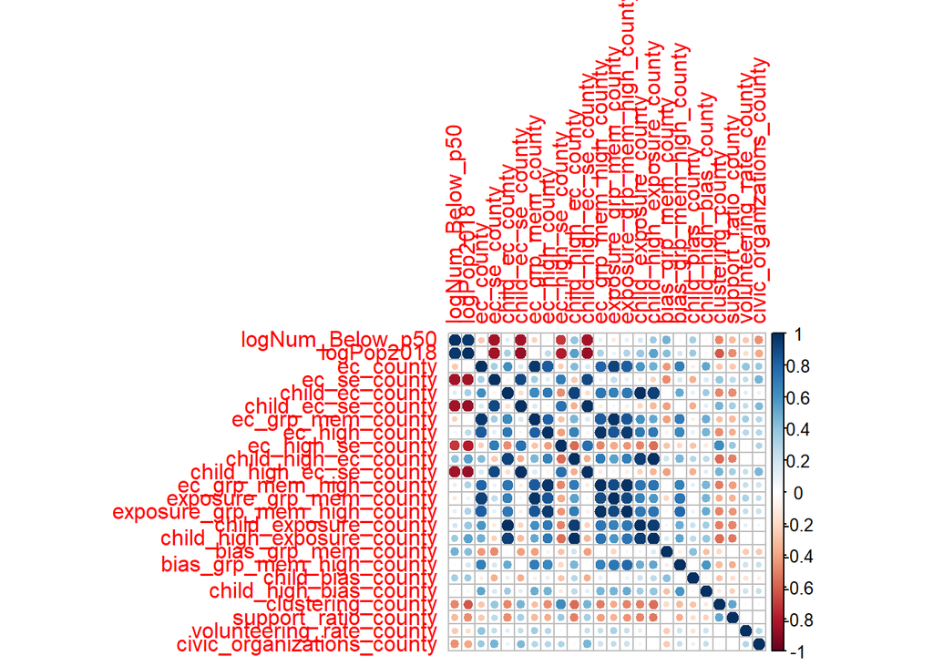

```r
corrplot(R, method = "circle")
```

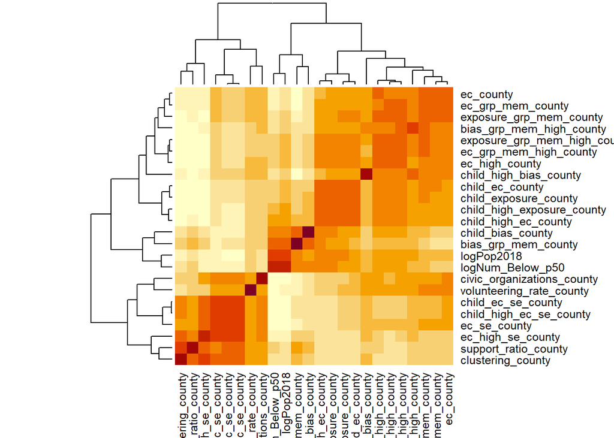

```r
heatmap(R)
```

Our data initially yields a correlation matrix and a heat map that highlights several clusters that suggest a possible intrinsic dimensionality of potentially 7. Assessment of these values will be core to our project going forward to determine the factorization of the data. Naturally as a number of dimensions are the calculated standard error for their previous respective dimension, we note that these values are indeed highly correlated together intrinsically. That said, we must now check to determine whether any influential outliers exist in the data, and whether their removal presents a dramatic change to these plots overall.

#### Identifying our Outliers

```r
CritVal = qchisq(p = 1-.05, df = 24)
covdata = cov(data, use = "pairwise.complete.obs")
Mal = matrix(ncol=24, nrow=24)
rownames(Mal) = colnames(data)
colnames(Mal) = colnames(data)
for(i in 1:24)
  {
  for(j in 1:24)
  {
    if( i!=j){
    Distances = mahalanobis(x=data[,c(i,j)], center = c(mean(data[,i]), mean(data[,j])), cov = cov(data[,c(i,j)],use = "pairwise.complete.obs"))
    Mal[i,j] = length(which(abs(Distances)>CritVal))
    }
  }}
sum(Mal[which(!is.na(Mal))]) / 2
```

```
## [1] 51
```

We see that we have 51 outliers. Our outliers are all found in the pairs of dimensions 21-24. Next We will change the values of these outliers to be NA.

#### Removing Outliers

```r
OutliersRemoved = data
for(i in 21:24)
  {
  for(j in 21:24)
  {
    if( i!=j){
    Distances = mahalanobis(x=OutliersRemoved[,c(i,j)], center = c(mean(OutliersRemoved[,i]), mean(OutliersRemoved[,j])), cov = cov(OutliersRemoved[,c(i,j)],use = "pairwise.complete.obs"))
    OutliersRemoved[which(abs(Distances)>CritVal),i] = NA
    OutliersRemoved[which(abs(Distances)>CritVal),j] = NA
    }
  }}
```

We have now created a new dataset “OutliersRemoved” to allow us to compare the correlation plots with our outliers included and with them removed.

#### Ensuring there are no remaining Outliers

```r
for(i in 1:24)
  {
  for(j in 1:24)
  {
    if( i!=j){
    Distances = mahalanobis(x=OutliersRemoved[,c(i,j)], center = c(mean(OutliersRemoved[,i]), mean(OutliersRemoved[,j])), cov = cov(OutliersRemoved[,c(i,j)],use = "pairwise.complete.obs"))
    Mal[i,j] = length(which(abs(Distances)>CritVal))
    }
  }}
sum(Mal[which(!is.na(Mal))]) / 2
```

```
## [1] 0
```

#### Reproducing Correlation Plots

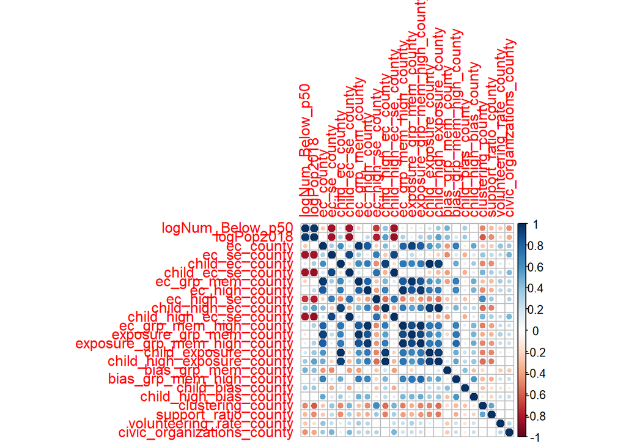

```r
CorData = cor(data, use = "pairwise.complete.obs")
AdjCor = cor(OutliersRemoved, use = "pairwise.complete.obs")
corrplot(CorData)
```

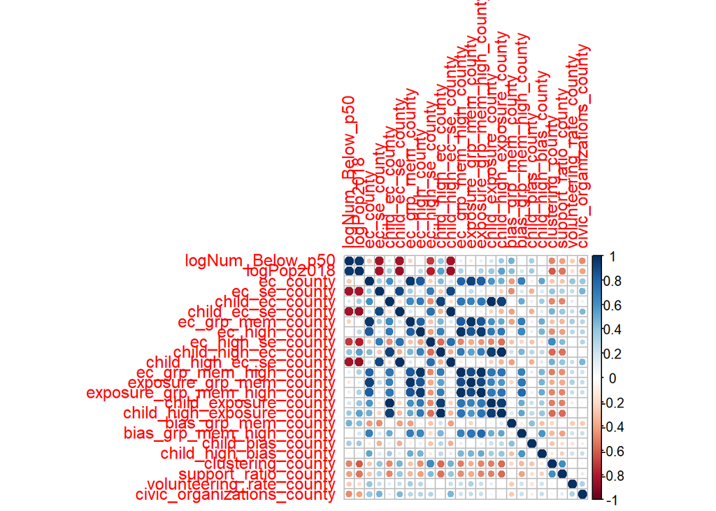

```r
corrplot(AdjCor)
```

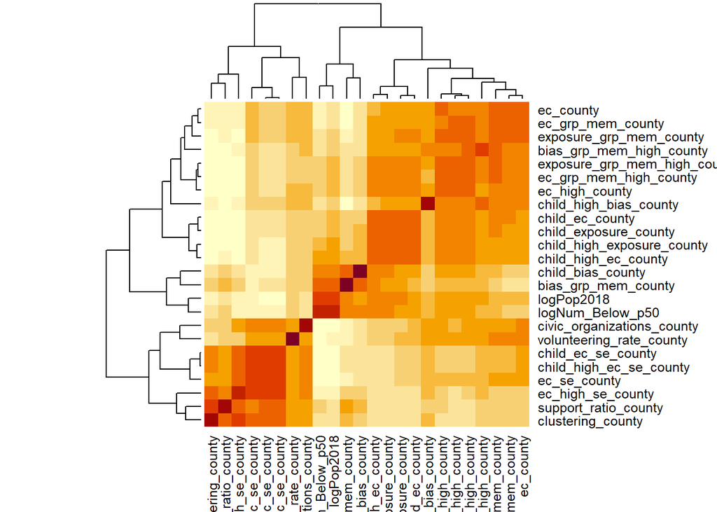

```r
heatmap(CorData)
```

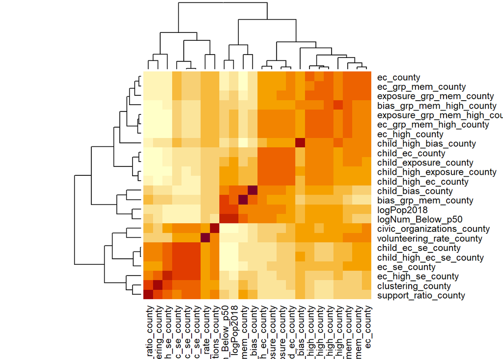

```r
heatmap(AdjCor)
```

It does not appear that there is any major changes to our correlation when the outliers have been removed. We see a slight change in the factor grouping of the first three dimensions, but otherwise it doesn’t appear that our outliers have any real effect on the correlation of our dimensions.